# CART – Hands-on

v-1.2

Prof. Dario Gregori – Dott. Corrado Lanera

# Outline

- Preamble
  - Aims
  - Packages
  - Functions
  - Data used
- Case study
  - Exploration
  - Basic tree model
  - Exhaustive tree model
  - Pruned tree model
- Classification exercise
  - Data set definition and Aims
  - Partitioning
  - Model setting and tuning
  - Honest performance estimation
  - Further considerations and improvements
- Links

# Preamble

## Aims

Main aim of this hands-on are:

1. Show an application of CARTs to a public health data case study
2. Show and use some different implementation of CART in R:
   - `tree`
   - `rpart`
   - `caret`
3. Perform a MLT task on CART

To illustrate how to achieve these objectives, we analyze median health cost levels per neighborhoods in California. Data includes geographical information (Longitude and Latitude) and administrative data (number of households, number of doctors, the percent of chronic patients and the median income of each neighborhood.

## Packages

```r
if (!requireNamespace('pacman')) {
    install.packages('pacman', dependencies = TRUE)
}
pacman::p_load(
    tree,
    rpart,
    caret,
    tidyverse
)
```

### `tree`

Original implementation of the CART algorithm by Brian Ripley (http://www.stats.ox.ac.uk/~ripley/)

```r
citation('tree')
```

```
  Brian Ripley (2018). tree: Classification and Regression
  Trees. R package version 1.0-39.
  https://CRAN.R-project.org/package=tree

A BibTeX entry for LaTeX users is

  @Manual{,
    title = {tree: Classification and Regression Trees},
    author = {Brian Ripley},
    year = {2018},
    note = {R package version 1.0-39},
    url = {https://CRAN.R-project.org/package=tree},
  }
```

### `rpart`

The `rpart::rpart()` function differs from the `tree::tree()` function mainly for the fact that it allows for surrogate variables, a way to manage missingness in the training data involving regressors (not the outcome!).

```r
citation('rpart')
```

```
  Terry Therneau and Beth Atkinson (2018). rpart: Recursive
  Partitioning and Regression Trees. R package version
  4.1-13. https://CRAN.R-project.org/package=rpart

A BibTeX entry for LaTeX users is

  @Manual{,
    title = {rpart: Recursive Partitioning and Regression Trees},
    author = {Terry Therneau and Beth Atkinson},
    year = {2018},
    note = {R package version 4.1-13},
    url = {https://CRAN.R-project.org/package=rpart},
  }
```

## Functions

### `tree`

```r
?tree::tree
```

```
tree(formula, data, subset, weights,

    na.action = na.pass,

    control   = tree.control(nobs, ...),  # options to control the algorithm

    split     = c("deviance", "gini"),

    [...]   # take a look at option `model` and `method` equal "model.frame"

    ...
)
```

```r
?tree::tree.control
```

```
tree.control(nobs,          # The number of observations in the training set

    mincut  = 5,                    # min number of obs in either child node

    minsize = 10,                               # smallest allowed node size

    mindev  = 0.01 # min within-node deviance as a fraction of the root node
                   # for the node to be split.
)
```

### `rpart`

```r
?tree::partition.tree                                               # ?plot.tree
```

```
partition.tree(tree,

    label = "yval",                 # column to be used to label the regions

    add   = FALSE,       # If TRUE, add to existing plot, or start a new one

    ordvars,        # The ordering of the variables to be used in a 2D plot.
                    # Character string of length 2 (the first will be the x)

    ...                                         # other graphical parameters
)
```

```r
?rpart::rpart
```

```
rpart(formula, data, weights, subset,

    na.action = na.rpart,    # `na.rpart` (default) deletes all observations
                             # for which y is missing, but keeps those
                             # in which one or more predictors are missing

    method, # If missing then the routine tries to make an intelligent guess

    control,                              # options to control the algorithm

    [...],

    ...
)
```

```r
?rpart::rpart.control
```

```
rpart.control(minsplit = 20,    # min obs that must exist in a node in order
                                # for a split to be attempted

    minbucket = round(minsplit/3),     # min obs in any terminal <leaf> node

    cp = 0.01,  # complexity parameter. Any split that does not decrease the
                # overall lack of fit by a factor of cp is not attempted.

    xval = 10,                        # number of folds for cross validation

    surrogatestyle = 0,        # controls the selection of a best surrogate.
                               # (read the documentation)

    maxdepth = 30,             # maximum depth of any node of the final tree

    [...],

    ...
    )
```

```r
?rpart::prune
```

```
prune(tree,

    cp,    # Complexity parameter to which the rpart object will be trimmed.

    ...
)
```

## Data used

```r
load(file.path('health_data'))
health_data
```

|  | Households | Latitude | Longitude | health_cost | doctors | perc_chronical | income | Long | Lat |
| --- | --- | --- | --- | --- | --- | --- | --- | --- | --- |
| 10956 | 436 | 33.76 | -117.88 | 12.232228 | 17 | 0.0043929564 | 1.7823 | -117.88 | 33.76 |
| 13307 | 557 | 34.08 | -117.62 | 11.624467 | 22 | 0.0037604291 | 3.1250 | -117.62 | 34.08 |
| 2889 | 341 | 35.39 | -118.99 | 10.922335 | 36 | 0.0033017078 | 1.8319 | -118.99 | 35.39 |
| 6536 | 199 | 34.05 | -118.05 | 11.996585 | 36 | 0.0021956522 | 3.7279 | -118.05 | 34.05 |
| 17982 | 565 | 37.31 | -121.95 | 12.705332 | 27 | 0.0044600939 | 3.5652 | -121.95 | 37.31 |
| 13189 | 324 | 34.09 | -117.70 | 11.710136 | 25 | 0.0030145719 | 3.6250 | -117.70 | 34.09 |
| 17590 | 754 | 37.31 | -121.91 | 12.714696 | 28 | 0.0054502688 | 3.6429 | -121.91 | 37.31 |
| 3544 | 1054 | 34.26 | -118.59 | 12.785771 | 20 | 0.0031751825 | 7.1670 | -118.59 | 34.26 |
| 16862 | 12 | 37.63 | -122.42 | 12.524526 | 46 | 0.0036666667 | 2.3750 | -122.42 | 37.63 |
| 17773 | 1037 | 37.36 | -121.85 | 11.980426 | 15 | 0.0031383577 | 3.0466 | -121.85 | 37.36 |

[output cut: 990 more lines]

```r
identical(health_data$Latitude, health_data$Lat)
```

```
[1] TRUE
```

```r
identical(health_data$Longitude, health_data$Long)
```

```
[1] TRUE
```

```r
health_data <- health_data %>%
    dplyr::select(-Latitude, -Longitude)
health_data
```

|  | Households | health_cost | doctors | perc_chronical | income | Long | Lat |
| --- | --- | --- | --- | --- | --- | --- | --- |
| 10956 | 436 | 12.232228 | 17 | 0.0043929564 | 1.7823 | -117.88 | 33.76 |
| 13307 | 557 | 11.624467 | 22 | 0.0037604291 | 3.1250 | -117.62 | 34.08 |
| 2889 | 341 | 10.922335 | 36 | 0.0033017078 | 1.8319 | -118.99 | 35.39 |
| 6536 | 199 | 11.996585 | 36 | 0.0021956522 | 3.7279 | -118.05 | 34.05 |
| 17982 | 565 | 12.705332 | 27 | 0.0044600939 | 3.5652 | -121.95 | 37.31 |
| 13189 | 324 | 11.710136 | 25 | 0.0030145719 | 3.6250 | -117.70 | 34.09 |
| 17590 | 754 | 12.714696 | 28 | 0.0054502688 | 3.6429 | -121.91 | 37.31 |
| 3544 | 1054 | 12.785771 | 20 | 0.0031751825 | 7.1670 | -118.59 | 34.26 |
| 16862 | 12 | 12.524526 | 46 | 0.0036666667 | 2.3750 | -122.42 | 37.63 |
| 17773 | 1037 | 11.980426 | 15 | 0.0031383577 | 3.0466 | -121.85 | 37.36 |

[output cut: 990 more lines]

# Case study: Health cost in California

## Exploration

First of all we take a look at the distribution of the variable involved and, in particular we plot a map of the region (based on the Lat end Long) colored with intensity proportional to the health cost per unit (the neighborhood).

```r
map_dbl(health_data, ~ is.na(.) %>% sum)
```

```
    Households    health_cost        doctors perc_chronical
             0              0              0              0
        income           Long            Lat
             0              0              0
```

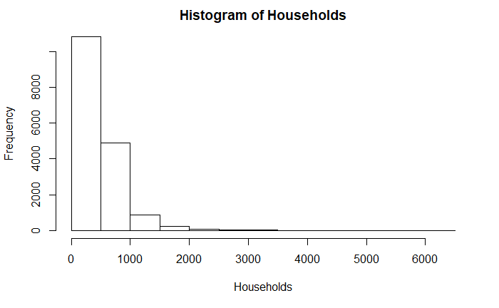

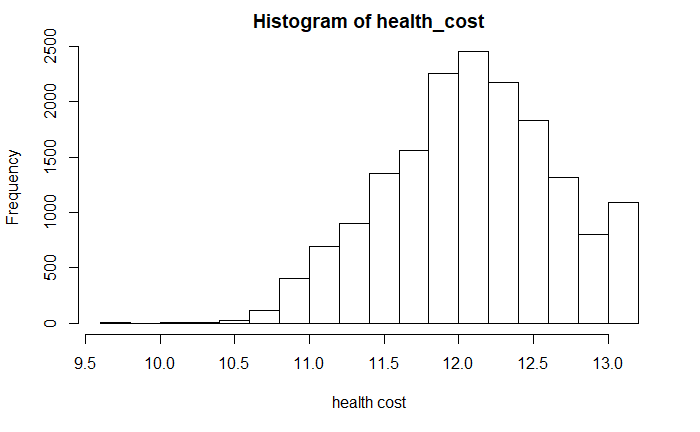

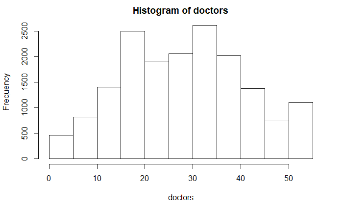

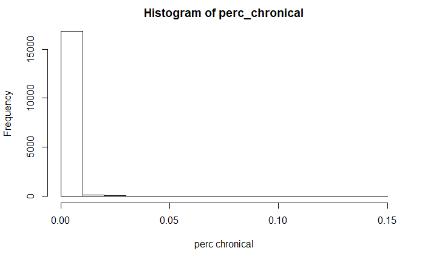

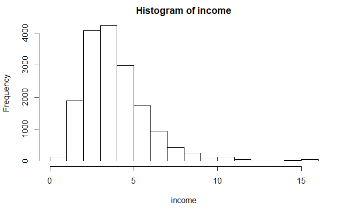

```r
walk(setdiff(names(health_data), c('Lat', 'Long')),
     ~ hist(health_data[[.]],
        main = paste0('Histogram of ', .),
        xlab = names(health_data[.]) %>% gsub(pattern = '_', replacement = ' ')
    )
)
```

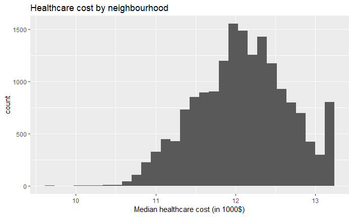

```r
ggplot(health_data, aes(health_cost)) +
    geom_histogram() +
    ggtitle("Healthcare cost by neighbourhood") +
    xlab("Median healthcare cost (in 1000$)")
```

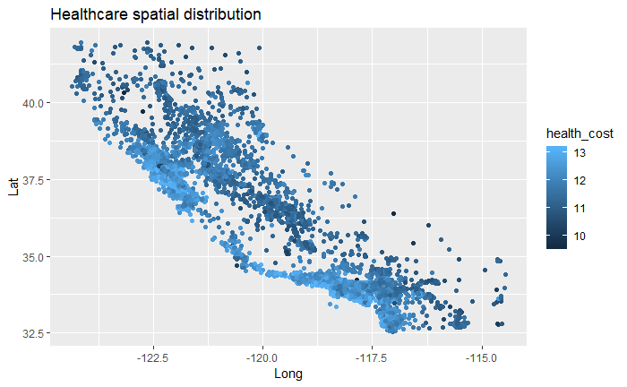

```r
ggplot(health_data, aes(x = Long, y = Lat)) +
    geom_point(aes(colour = health_cost)) +
    ggtitle("Healthcare spatial distribution")
```

## Basic tree model

Start to fit a partition based **only on latitude and longitude**

Take a look at the tree in graphical and textual representation.

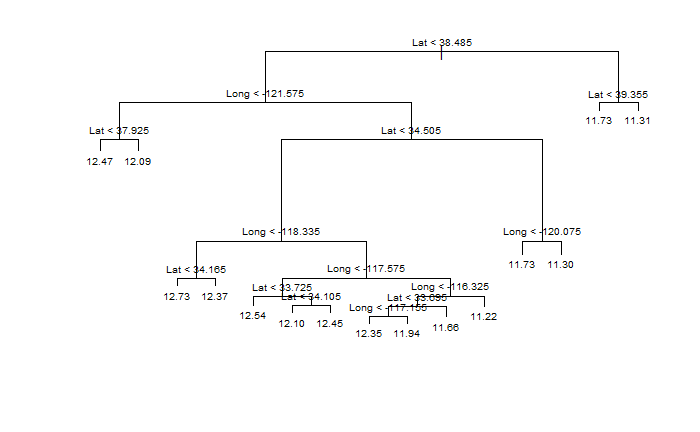

```r
tree_model <- tree(health_cost ~ Long + Lat,
    data = health_data
)
plot(tree_model)
text(tree_model, cex = 0.6)
```

```r
tree_model
```

```
node), split, n, deviance, yval
      * denotes terminal node

  1) root 17000 5485.00 12.08
    2) Lat < 38.485 15307 4717.00 12.14
      4) Long < -121.575 3866  802.30 12.39
        8) Lat < 37.925 2981  554.70 12.47 *
        9) Lat > 37.925 885  149.80 12.09 *
      5) Long > -121.575 11441 3597.00 12.05
       10) Lat < 34.505 9034 2171.00 12.20
         20) Long < -118.335 1997  315.40 12.55
           40) Lat < 34.165 992  143.00 12.73 *
           41) Lat > 34.165 1005  106.60 12.37 *
         21) Long > -118.335 7037 1535.00 12.10
           42) Long < -117.575 4692  800.90 12.20
             84) Lat < 33.725 582   93.77 12.54 *
             85) Lat > 33.725 4110  633.60 12.16
              170) Lat < 34.105 3457  456.70 12.10 *
              171) Lat > 34.105 653  111.10 12.45 *
           43) Long > -117.575 2345  574.00 11.88
             86) Long < -116.325 2171  466.80 11.94
              172) Lat < 33.695 1380  269.60 12.10
                344) Long < -117.155 521  106.30 12.35 *
                345) Long > -117.155 859  107.20 11.94 *
              173) Lat > 33.695 791  103.60 11.66 *
             87) Long > -116.325 174   24.63 11.22 *
       11) Lat > 34.505 2407  533.20 11.51
         22) Long < -120.075 1203  236.40 11.73 *
         23) Long > -120.075 1204  187.80 11.30 *
    3) Lat > 38.485 1693  316.40 11.59
      6) Lat < 39.355 1139  196.80 11.73 *
      7) Lat > 39.355 554   54.77 11.31 *
```

To better understand the results, put them on the map

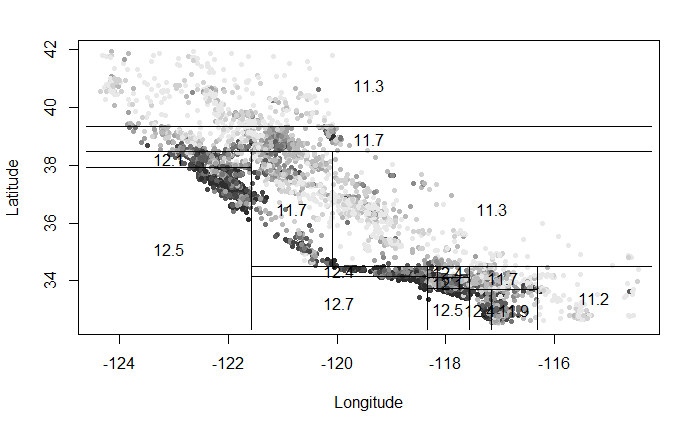

```r
## create the gray scale for the basic plot system for each observation
#
cost_deciles <- quantile(health_data$health_cost,
    seq(from = 0,  to = 1, length.out = 10)
)
cut_health   <- cut(health_data$health_cost, cost_deciles,
                     include.lowest = TRUE
)
intensity <- gray(10:2/11)[cut_health]
## plot the map using the base plot system and add the partition to it
#
plot(health_data$Long, health_data$Lat,
     col  = intensity,
     pch  = 20, # plot character: filled dot.
     xlab = "Longitude",
     ylab = "Latitude"
)
partition.tree(tree_model, ordvars = c("Long","Lat"), add = TRUE)
```

## Exaustive tree model

Now, we include all the other information in the tree.

It is useful to perform cross validation and management of missing data in the covariates (even if we know that in this data set there are no missing data). After that, we perform some pruning of the trees we train.

For these reasons we start to use the functions provided by the `rpart` package.

```r
rpart_model <- rpart(
    health_cost ~ .,
    data    = health_data,
    control = rpart.control(
            cp   = 0.001,
            xval = 10
    )
)
plot(rpart_model,
     uniform  = TRUE,
     compress = TRUE,
     margin   = 0.05,
     branch   = 0.5
) # ?plot.rpart
text(rpart_model, use.n = FALSE)
```

[figure not shown]

```r
title("Regression Tree for Healthcare cost")
par(mfrow = c(1, 2))                             # two plots on one page
```

```r
rsq.rpart(rpart_model) # plots the jackknifed error versus the number of
```

```
Regression tree:
rpart(formula = health_cost ~ ., data = health_data, control = rpart.control(cp = 0.001,
    xval = 10))

Variables actually used in tree construction:
[1] doctors        income         Lat            Long
[5] perc_chronical

Root node error: 5485.5/17000 = 0.32267

n= 17000

          CP nsplit rel error  xerror      xstd
1  0.3073910      0   1.00000 1.00006 0.0097233
2  0.0778911      1   0.69261 0.69355 0.0073007
```

[output cut: 60 more lines]

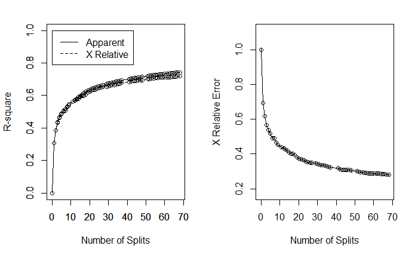

```r
                       # splits
par(mfrow = c(1, 1))
```

```r
printcp(rpart_model)
```

```
Regression tree:
rpart(formula = health_cost ~ ., data = health_data, control = rpart.control(cp = 0.001,
    xval = 10))

Variables actually used in tree construction:
[1] doctors        income         Lat            Long
[5] perc_chronical

Root node error: 5485.5/17000 = 0.32267

n= 17000

          CP nsplit rel error  xerror      xstd
1  0.3073910      0   1.00000 1.00006 0.0097233
2  0.0778911      1   0.69261 0.69355 0.0073007
```

[output cut: 60 more lines]

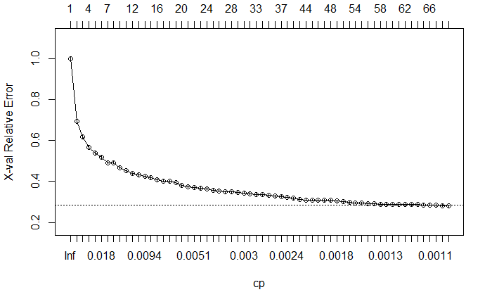

```r
plotcp(rpart_model)
```

```r
summary(rpart_model)
```

```
Call:
rpart(formula = health_cost ~ ., data = health_data, control = rpart.control(cp = 0.001,
    xval = 10))
  n= 17000

            CP nsplit rel error    xerror        xstd
1  0.307390975      0 1.0000000 1.0000633 0.009723277
2  0.077891065      1 0.6926090 0.6935537 0.007300714
3  0.051824439      2 0.6147180 0.6166326 0.007090761
4  0.028031598      3 0.5628935 0.5668223 0.006688137
5  0.022159438      4 0.5348619 0.5395289 0.006568762
6  0.014116095      5 0.5127025 0.5172976 0.006538509
7  0.014110074      6 0.4985864 0.4922068 0.006322341
8  0.013581372      7 0.4844763 0.4922068 0.006322341
9  0.011195842      8 0.4708949 0.4680675 0.006099062
10 0.010920969      9 0.4596991 0.4515363 0.006040462
11 0.009796116     11 0.4378572 0.4374298 0.005989794
12 0.009675764     12 0.4280610 0.4326258 0.005949623
13 0.009169343     13 0.4183853 0.4246526 0.005860795
14 0.008546754     14 0.4092159 0.4190426 0.005805050
15 0.007977441     15 0.4006692 0.4080751 0.005746642
16 0.007593761     16 0.3926917 0.4022384 0.005704767
17 0.007564138     17 0.3850980 0.4004402 0.005684269
18 0.007325625     18 0.3775338 0.3961184 0.005674318
19 0.006005941     19 0.3702082 0.3800333 0.005620312
20 0.005579705     20 0.3642023 0.3751898 0.005652558
21 0.004594628     21 0.3586226 0.3693634 0.005598057
22 0.004390029     22 0.3540279 0.3667967 0.005592140
23 0.004345713     23 0.3496379 0.3652171 0.005577169
24 0.003401028     24 0.3452922 0.3578041 0.005524671
25 0.003185076     25 0.3418912 0.3536701 0.005497896
26 0.003141006     26 0.3387061 0.3494729 0.005465538
27 0.003121257     27 0.3355651 0.3485068 0.005463045
28 0.003036617     29 0.3293226 0.3463103 0.005463328
29 0.003031175     30 0.3262860 0.3440649 0.005451516
30 0.002751416     31 0.3232548 0.3404290 0.005450852
31 0.002675755     32 0.3205034 0.3363280 0.005405694
32 0.002516938     33 0.3178276 0.3353145 0.005400593
33 0.002491245     34 0.3153107 0.3321464 0.005372730
34 0.002480863     35 0.3128194 0.3288179 0.005298045
```

[output cut: 1207 more lines]

```
      Households     < 381         to the left,  improve=0.05289928, (0 missing)
      income         < 4.13095     to the left,  improve=0.05106311, (0 missing)
      perc_chronical < 0.003892792 to the right, improve=0.02239490, (0 missing)
  Surrogate splits:
      Lat        < 36.885      to the left,  agree=0.907, adj=0.528, (0 split)
      Households < 14.5        to the left,  agree=0.813, adj=0.056, (0 split)

Node number 1765: 273 observations
  mean=12.46692, MSE=0.06372342

Node number 3528: 36 observations
  mean=11.62969, MSE=0.1439023

Node number 3529: 146 observations
  mean=12.35492, MSE=0.06142945
```

## Pruned tree model

Sometimes, it can be useful to have a smaller tree suitable for *human* interpretation instead of a more accurate *machine* prediction.

This way, we can prune the tree to a higher level of `cp` to obtain a tree with fewer leaves. Hence, even if we retain less leaves, the data in each one of them were selected by the tree to minimize the impurity.

```r
rpart_prune <- prune(rpart_model, cp = 0.02) # pruning the tree
plot(rpart_prune,
     uniform  = TRUE,
     compress = TRUE,
     margin   = 0.06,
     branch   = 0.5
)
text(rpart_prune)
```

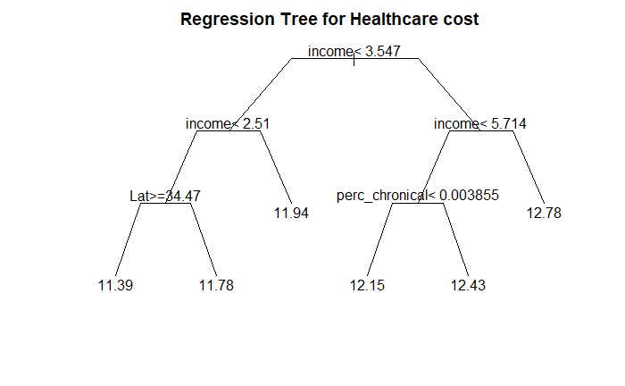

```r
title("Regression Tree for Healthcare cost")
```

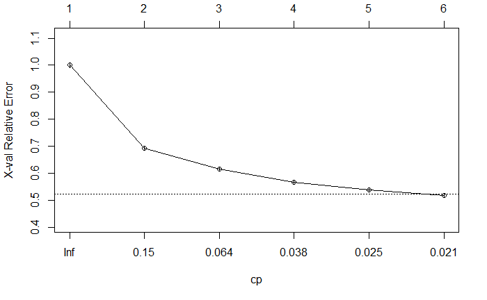

```r
plotcp(rpart_prune)
par(mfrow = c(1, 2))   # two plots on one page
```

```r
rsq.rpart(rpart_prune) # plots the jackknifed error versus the number of
```

```
Regression tree:
rpart(formula = health_cost ~ ., data = health_data, control = rpart.control(cp = 0.001,
    xval = 10))

Variables actually used in tree construction:
[1] income         Lat            perc_chronical

Root node error: 5485.5/17000 = 0.32267

n= 17000

        CP nsplit rel error  xerror      xstd
1 0.307391      0   1.00000 1.00006 0.0097233
2 0.077891      1   0.69261 0.69355 0.0073007
3 0.051824      2   0.61472 0.61663 0.0070908
4 0.028032      3   0.56289 0.56682 0.0066881
5 0.022159      4   0.53486 0.53953 0.0065688
6 0.020000      5   0.51270 0.51730 0.0065385
```

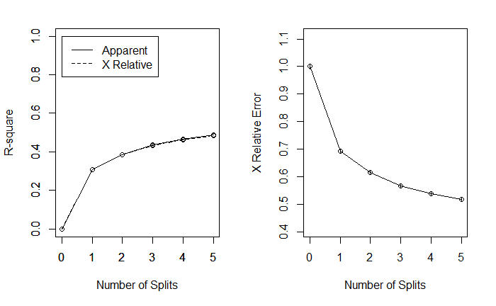

```r
                       # splits
par(mfrow = c(1, 1))
```

Let us see the data distribution on the leaves:

```
`data_frame()` is deprecated, use `tibble()`.
```

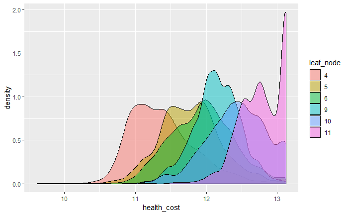

```r
health_data %>%
    dplyr::select(health_cost) %>%
    bind_cols(rpart_prune$where %>%
    data_frame(leaf_node = factor(.))) %>%
    ggplot(aes(health_cost, fill = leaf_node)) +
    geom_density(alpha = 0.5)
```

# Classification exercise

> using `caret`’s `rpart` for trees (same data)

## Data set definition and Aims

- Create a binary outcome, starting from the health cost (“high cost” for health_cost higher than 80% of the distribution)
- Aims:
  - scientific: predict “high” and “low” health cost class in California
  - MLT : max cross validate accuracy on test set

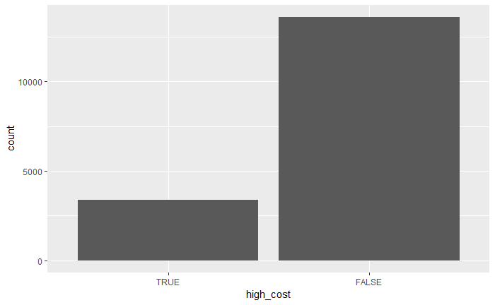

```r
health_data_class <- health_data  %>%
    mutate(high_cost = (health_cost > quantile(health_cost, 0.8)) %>%
               factor(levels = c(TRUE, FALSE))
    ) %>%
    dplyr::select(-health_cost)
ggplot(health_data_class, aes(high_cost)) +
    geom_bar()
```

## Partitioning

```r
set.seed(1)
train_idx <- caret::createDataPartition(health_data_class$high_cost,
                p = 0.7
)[[1]]
train_set <- health_data_class[train_idx, ]
test_set  <- health_data_class[-train_idx, ]
```

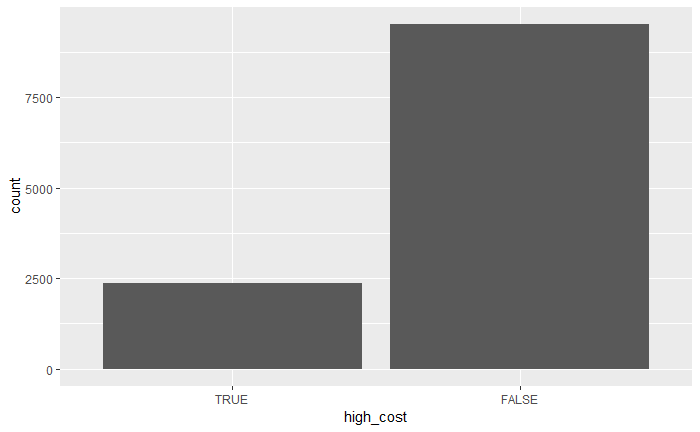

```r
ggplot(train_set, aes(high_cost)) +
    geom_bar()
```

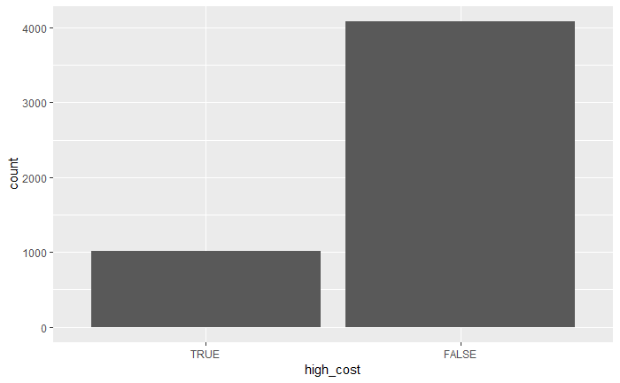

```r
ggplot(test_set, aes(high_cost)) +
    geom_bar()
```

## Model setting and tuning

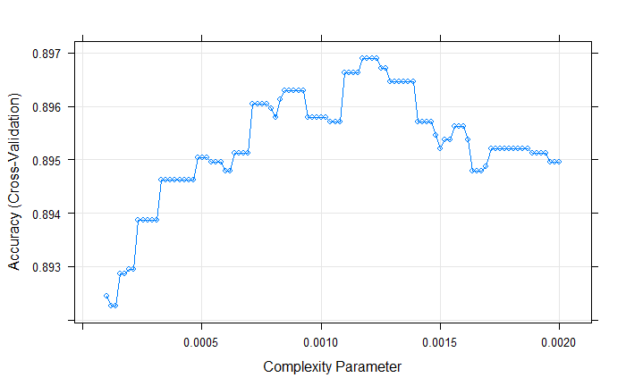

```r
set.seed(1234)
tune_grid <- expand.grid(
    # .cp = seq(from = 1e-3 ,to = 1e-1 , length.out = 50)
    # .cp = seq(from = 1e-4 ,to = 1e-2 , length.out = 50)
     .cp = seq(from = 1e-4 ,to = 2e-3 , length.out = 100)
)
caret_rpart <- train(high_cost ~ .,
    data = train_set,
    method    = "rpart",
    metric    = "Accuracy",
    trControl = trainControl(
        method ='cv',
        number = 10
    ),
    tuneGrid = tune_grid
)
plot(caret_rpart)
```

```r
plot(caret_rpart$finalModel,
     uniform  = TRUE,
     compress = TRUE,
     margin   = 0.06,
     branch   = 0.5
)
text(caret_rpart$finalModel) # ?test.rpart
```

[figure not shown]

```r
title("Classification Tree for High Healthcare cost")
```

## Honest performance estimation

```r
y_hat_train <- predict(caret_rpart, train_set)
confusionMatrix(train_set$high_cost, y_hat_train)
```

```
Confusion Matrix and Statistics

          Reference
Prediction TRUE FALSE
     TRUE  1775   605
     FALSE  381  9139

               Accuracy : 0.9171
                 95% CI : (0.912, 0.922)
    No Information Rate : 0.8188
    P-Value [Acc > NIR] : < 2.2e-16

                  Kappa : 0.7316
 Mcnemar's Test P-Value : 1.232e-12

            Sensitivity : 0.8233
            Specificity : 0.9379
         Pos Pred Value : 0.7458
         Neg Pred Value : 0.9600
             Prevalence : 0.1812
         Detection Rate : 0.1492
   Detection Prevalence : 0.2000
      Balanced Accuracy : 0.8806

       'Positive' Class : TRUE
```

```r
y_hat_test <- predict(caret_rpart, test_set)
confusionMatrix(test_set$high_cost, y_hat_test)
```

```
Confusion Matrix and Statistics

          Reference
Prediction TRUE FALSE
     TRUE   715   305
     FALSE  216  3864

               Accuracy : 0.8978
                 95% CI : (0.8892, 0.906)
    No Information Rate : 0.8175
    P-Value [Acc > NIR] : < 2.2e-16

                  Kappa : 0.67
 Mcnemar's Test P-Value : 0.0001156

            Sensitivity : 0.7680
            Specificity : 0.9268
         Pos Pred Value : 0.7010
         Neg Pred Value : 0.9471
             Prevalence : 0.1825
         Detection Rate : 0.1402
   Detection Prevalence : 0.2000
      Balanced Accuracy : 0.8474

       'Positive' Class : TRUE
```

## Further consideration and improvements

- Can the performance increase by considering weights in the training phase?
- Can you use `caret` to perform this kind of improvement?

> Remember that weighting has to be done **after** the cross validation partition if you want to remain honest… (why?)
- Can you really say to be *honest* if you decide to use weights *after* you have seen (on the test set) that your classification accuracy was unbalanced the same way the class was?

# Links

- R help: `?`